# TD Final noté : Analyse des Avis et Alertes ANSSI avec Enrichissement des CVE

## Projet de Consolidation, Visualisation et Machine Learning

## 1. Importation des bibliothèques et chargement des données

Dans cette section, nous chargeons les bibliothèques d'analyse de données (`pandas`, `numpy`), de visualisation (`matplotlib`, `seaborn`) et les modules de `scikit-learn` pour le Machine Learning. Nous importons ensuite les données consolidées issues de notre pipeline dans un DataFrame pandas.

```python
import pandas as pd
import numpy as np
import matplotlib.pyplot as plt
import seaborn as sns
from datetime import datetime
import warnings
warnings.filterwarnings('ignore')
sns.set_theme(style="whitegrid")
```

```python
# Chargement des données d'Avis et d'Alertes depuis le backup
df_avis = pd.read_csv("backup/full_cleaned_AVIS.csv")
df_alert = pd.read_csv("backup/full_cleaned_ALERT.csv")

# Identification des types de bulletins
df_avis["Type"] = "Avis"
df_alert["Type"] = "Alerte"

# Combinaison des données
df = pd.concat([df_avis, df_alert], ignore_index=True)

# Nettoyage et renommage des colonnes pour correspondre aux attentes du notebook
def clean_numeric(val):
    if pd.isna(val):
        return np.nan
    val_str = str(val).strip()
    if val_str.lower() in ["non disponible", "nan", "", "none", "n/a"]:
        return np.nan
    try:
        return float(val_str)
    except:
        return np.nan

def get_base_severity(score):
    if pd.isna(score):
        return "Non disponible"
    try:
        score = float(score)
    except:
        return "Non disponible"
    if score == 0.0:
        return "NONE"
    elif 0.1 <= score <= 3.9:
        return "LOW"
    elif 4.0 <= score <= 6.9:
        return "MEDIUM"
    elif 7.0 <= score <= 8.9:
        return "HIGH"
    elif 9.0 <= score <= 10.0:
        return "CRITICAL"
    else:
        return "Non disponible"

# Renommer les colonnes existantes
df = df.rename(columns={
    "title": "Titre",
    "published": "Date publication",
    "cve_id": "CVE",
    "cvss_score": "Score CVSS",
    "cwe": "Type CWE",
    "epss_score": "Score EPSS",
    "vendor": "Vendor",
    "product": "Produit",
    "versions": "Versions affectées",
    "description_cve": "Description",
    "link": "Lien bulletin"
})

df["Score CVSS"] = df["Score CVSS"].apply(clean_numeric)
df["Score EPSS"] = df["Score EPSS"].apply(clean_numeric)
df["Base Severity"] = df["Score CVSS"].apply(get_base_severity)

df["Type CWE"] = df["Type CWE"].fillna("Non disponible").astype(str).str.strip().replace({"nan": "Non disponible", "": "Non disponible", "None": "Non disponible"})
df["Vendor"] = df["Vendor"].fillna("Non disponible").astype(str).str.strip().replace({"nan": "Non disponible", "": "Non disponible", "None": "Non disponible"})

# Tri par date de publication (décroissante) pour trier les données chronologiquement
df = df.sort_values(by="Date publication", ascending=False).reset_index(drop=True)

print(f"Nombre de lignes : {df.shape[0]}")
print(f"Nombre de colonnes : {df.shape[1]}")

# Afficher un échantillon représentatif contenant à la fois des Avis et des Alertes
pd.concat([df[df["Type"] == "Avis"].head(3), df[df["Type"] == "Alerte"].head(2)])
```

```
Nombre de lignes : 3569
Nombre de colonnes : 17
```

|  | Unnamed: 0 | Titre | description_alert | Lien bulletin | Date publication | alert_title | CVE | Description | Score CVSS | Type CWE | cwe_desc | Score EPSS | Vendor | Produit | Versions affectées | Type | Base Severity |
| --- | --- | --- | --- | --- | --- | --- | --- | --- | --- | --- | --- | --- | --- | --- | --- | --- | --- |
| 14 | 1975 | Multiples vulnérabilités dans Microsoft Window... | De multiples vulnérabilités ont été découverte... | https://www.cert.ssi.gouv.fr/avis/CERTFR-2026-... | Wed, 10 Jun 2026 00:00:00 +0000 | Multiples vulnérabilités dans Microsoft Window... | CVE-2026-42916 | Integer underflow (wrap or wraparound) in Wind... | 7.8 | CWE-190 | CWE-190: Integer Overflow or Wraparound | 0.00082 | Microsoft | Windows Server 2022 | ['10.0.20348.0'] | Avis | HIGH |
| 15 | 1979 | Multiples vulnérabilités dans Microsoft Window... | De multiples vulnérabilités ont été découverte... | https://www.cert.ssi.gouv.fr/avis/CERTFR-2026-... | Wed, 10 Jun 2026 00:00:00 +0000 | Multiples vulnérabilités dans Microsoft Window... | CVE-2026-47648 | Untrusted search path in Windows Storage allow... | 7.0 | CWE-426 | CWE-426: Untrusted Search Path | 0.00110 | Microsoft | Windows 10 Version 1809 | ['10.0.17763.0'] | Avis | HIGH |
| 16 | 1978 | Multiples vulnérabilités dans Microsoft Window... | De multiples vulnérabilités ont été découverte... | https://www.cert.ssi.gouv.fr/avis/CERTFR-2026-... | Wed, 10 Jun 2026 00:00:00 +0000 | Multiples vulnérabilités dans Microsoft Window... | CVE-2026-47648 | Untrusted search path in Windows Storage allow... | 7.0 | CWE-426 | CWE-426: Untrusted Search Path | 0.00110 | Microsoft | Windows 10 Version 1607 | ['10.0.14393.0'] | Avis | HIGH |
| 0 | 135 | [MàJ] Vulnérabilité dans Cisco Catalyst SD-WAN... | Une vulnérabilité a été découverte dans Cisco ... | https://www.cert.ssi.gouv.fr/alerte/CERTFR-202... | Wed, 25 Feb 2026 00:00:00 +0000 | [MàJ] Vulnérabilité dans Cisco Catalyst SD-WAN... | CVE-2026-20127 | A vulnerability in the peering authentication ... | 10.0 | CWE-287 | Improper Authentication | 0.58950 | Cisco | Cisco Catalyst SD-WAN Manager | ['20.1.12', '19.2.1', '18.4.4', '18.4.5', '20.... | Alerte | CRITICAL |
| 1 | 130 | [MàJ] Vulnérabilité dans Cisco Catalyst SD-WAN... | Une vulnérabilité a été découverte dans Cisco ... | https://www.cert.ssi.gouv.fr/alerte/CERTFR-202... | Wed, 25 Feb 2026 00:00:00 +0000 | [MàJ] Vulnérabilité dans Cisco Catalyst SD-WAN... | CVE-2022-20775 | A vulnerability in the CLI of Cisco SD-WAN Sof... | 7.8 | CWE-25 | Path Traversal: '/../filedir' | 0.00385 | Cisco | Cisco Catalyst SD-WAN | ['18.3.1', '19.2.1', '17.2.4', '19.3.0', '18.3... | Alerte | HIGH |

## 2. Exploration et Nettoyage des Données

Nous vérifions les types de données, les statistiques descriptives et le taux de valeurs manquantes pour chaque colonne afin de préparer l'étape de visualisation et de modélisation.

```python
# Calcul du nombre et pourcentage de valeurs manquantes
missing = df.isnull().sum()
missing_pct = (missing / len(df)) * 100
missing_df = pd.DataFrame({'Valeurs manquantes': missing, 'Pourcentage (%)': missing_pct})
print("=== Analyse des valeurs manquantes ===")
print(missing_df.round(2))
```

```
=== Analyse des valeurs manquantes ===
                    Valeurs manquantes  Pourcentage (%)
Unnamed: 0                           0             0.00
Titre                                0             0.00
description_alert                    0             0.00
Lien bulletin                        0             0.00
Date publication                     0             0.00
alert_title                          0             0.00
CVE                                  0             0.00
Description                          0             0.00
Score CVSS                         809            22.67
Type CWE                             0             0.00
cwe_desc                             4             0.11
Score EPSS                           0             0.00
Vendor                               0             0.00
Produit                             13             0.36
Versions affectées                 102             2.86
Type                                 0             0.00
Base Severity                        0             0.00
```

```python
print("=== Statistiques descriptives pour les scores numériques ===")
df[['Score CVSS', 'Score EPSS']].describe()
```

```
=== Statistiques descriptives pour les scores numériques ===
```

|  | Score CVSS | Score EPSS |
| --- | --- | --- |
| count | 2760.000000 | 3569.00000 |
| mean | 7.336087 | 0.02294 |
| std | 1.280711 | 0.14454 |
| min | 2.600000 | -1.00000 |
| 25% | 7.000000 | 0.00049 |
| 50% | 7.800000 | 0.00070 |
| 75% | 7.900000 | 0.00091 |
| max | 10.000000 | 0.94412 |

## 3. Visualisations Graphiques

Nous réalisons une variété de graphiques pour comprendre la distribution et la relation entre les indicateurs de vulnérabilités (CVSS, EPSS, CWE, Vendors, etc.).

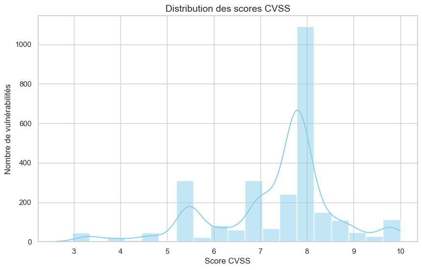

```python
plt.figure(figsize=(10, 6))
# On supprime les NaN pour le tracé de la distribution
df_cvss_clean = df.dropna(subset=['Score CVSS'])
sns.histplot(data=df_cvss_clean, x='Score CVSS', bins=20, kde=True, color='skyblue')
plt.title("Distribution des scores CVSS", fontsize=14)
plt.xlabel("Score CVSS", fontsize=12)
plt.ylabel("Nombre de vulnérabilités", fontsize=12)
plt.savefig("cvss_distribution.png", dpi=100, bbox_inches='tight')
plt.show()
```

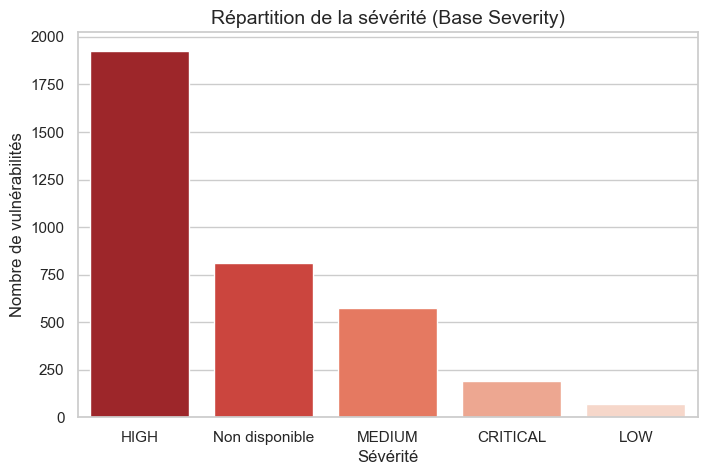

```python
plt.figure(figsize=(8, 5))
severity_counts = df['Base Severity'].value_counts()
sns.barplot(x=severity_counts.index, y=severity_counts.values, palette="Reds_r")
plt.title("Répartition de la sévérité (Base Severity)", fontsize=14)
plt.xlabel("Sévérité", fontsize=12)
plt.ylabel("Nombre de vulnérabilités", fontsize=12)
plt.savefig("severity_distribution.png", dpi=100, bbox_inches='tight')
plt.show()
```

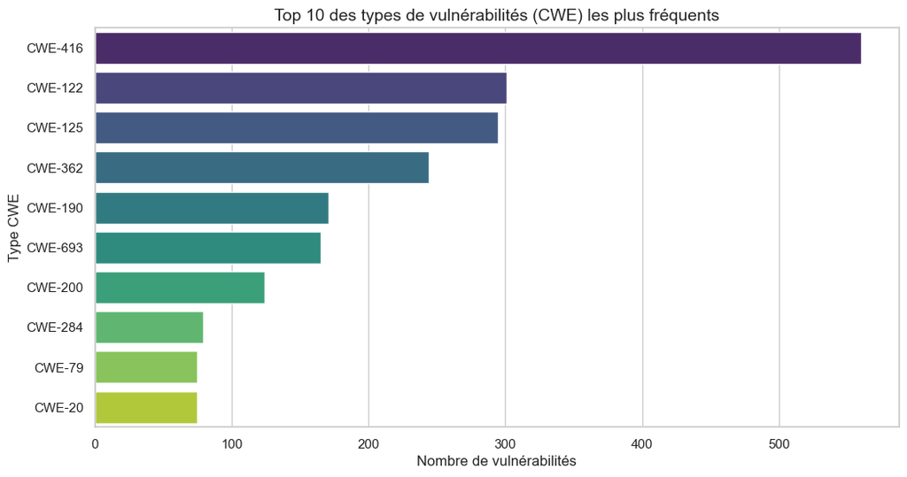

```python
plt.figure(figsize=(12, 6))
# Filtrer les valeurs CWE vides ou indésirables
df_cwe = df[df['Type CWE'].notnull() & (df['Type CWE'] != "Non disponible") & (df['Type CWE'] != "")]
top_cwes = df_cwe['Type CWE'].value_counts().head(10)
sns.barplot(y=top_cwes.index, x=top_cwes.values, palette="viridis")
plt.title("Top 10 des types de vulnérabilités (CWE) les plus fréquents", fontsize=14)
plt.xlabel("Nombre de vulnérabilités", fontsize=12)
plt.ylabel("Type CWE", fontsize=12)
plt.savefig("top_cwes.png", dpi=100, bbox_inches='tight')
plt.show()
```

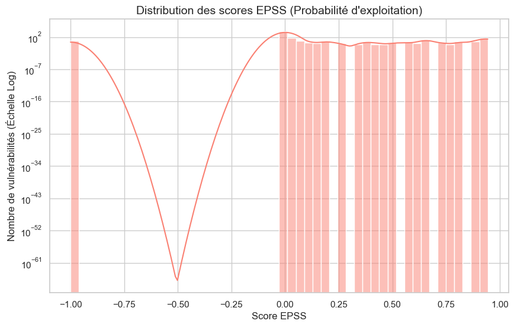

```python
plt.figure(figsize=(10, 6))
df_epss_clean = df.dropna(subset=['Score EPSS'])
sns.histplot(data=df_epss_clean, x='Score EPSS', bins=50, kde=True, color='salmon')
plt.title("Distribution des scores EPSS (Probabilité d'exploitation)", fontsize=14)
plt.xlabel("Score EPSS", fontsize=12)
plt.ylabel("Nombre de vulnérabilités (Échelle Log)", fontsize=12)
plt.yscale('log') # Utilisation de l'échelle log à cause de la forte asymétrie
plt.savefig("epss_distribution.png", dpi=100, bbox_inches='tight')
plt.show()
```

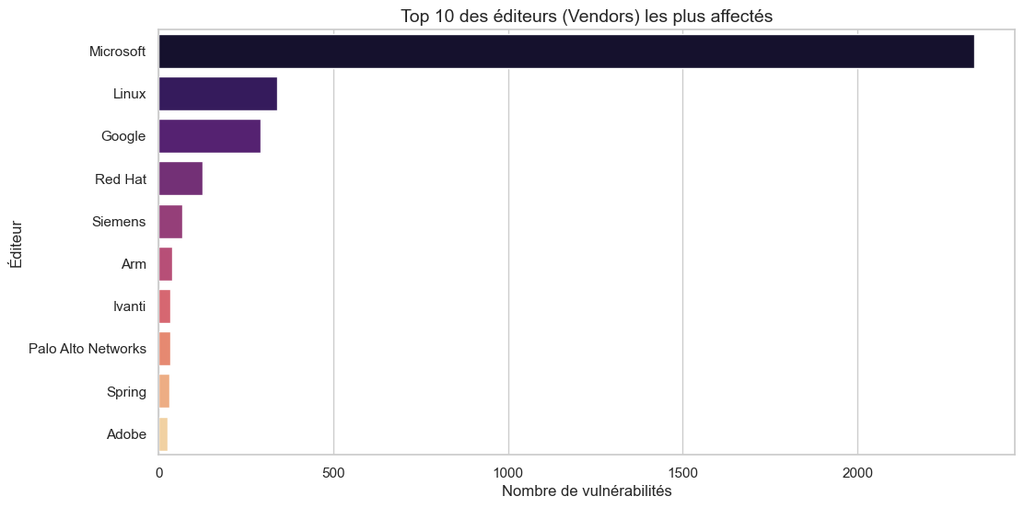

```python
plt.figure(figsize=(12, 6))
df_vendor = df[df['Vendor'].notnull() & (df['Vendor'] != "Non disponible") & (df['Vendor'] != "")]
top_vendors = df_vendor['Vendor'].value_counts().head(10)
sns.barplot(y=top_vendors.index, x=top_vendors.values, palette="magma")
plt.title("Top 10 des éditeurs (Vendors) les plus affectés", fontsize=14)
plt.xlabel("Nombre de vulnérabilités", fontsize=12)
plt.ylabel("Éditeur", fontsize=12)
plt.savefig("top_vendors.png", dpi=100, bbox_inches='tight')
plt.show()
```

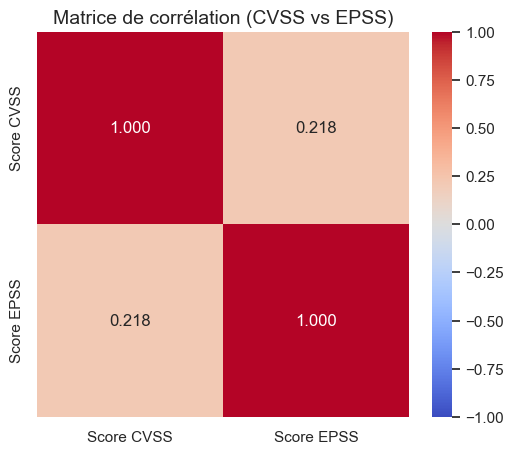

```python
plt.figure(figsize=(6, 5))
corr = df[['Score CVSS', 'Score EPSS']].corr()
sns.heatmap(corr, annot=True, cmap="coolwarm", vmin=-1, vmax=1, fmt=".3f")
plt.title("Matrice de corrélation (CVSS vs EPSS)", fontsize=14)
plt.savefig("correlation_heatmap.png", dpi=100, bbox_inches='tight')
plt.show()
```

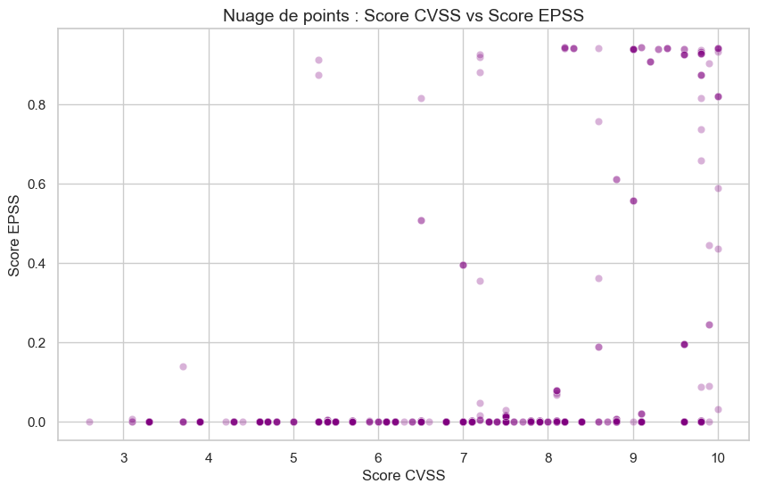

```python
plt.figure(figsize=(10, 6))
sns.scatterplot(data=df.dropna(subset=['Score CVSS', 'Score EPSS']), x='Score CVSS', y='Score EPSS', alpha=0.3, color='purple')
plt.title("Nuage de points : Score CVSS vs Score EPSS", fontsize=14)
plt.xlabel("Score CVSS", fontsize=12)
plt.ylabel("Score EPSS", fontsize=12)
plt.savefig("cvss_vs_epss.png", dpi=100, bbox_inches='tight')
plt.show()
```

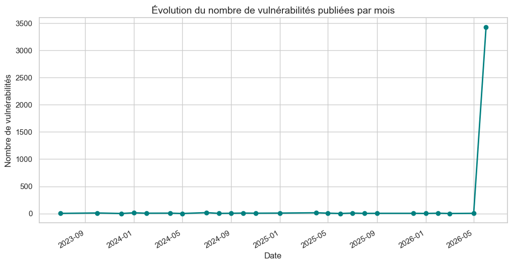

```python
plt.figure(figsize=(12, 6))
df_time = df.copy()
df_time['Date publication'] = pd.to_datetime(df_time['Date publication'], errors='coerce')
df_time_clean = df_time.dropna(subset=['Date publication'])
df_time_grouped = df_time_clean.groupby(df_time_clean['Date publication'].dt.to_period('M')).size()
df_time_grouped.index = df_time_grouped.index.to_timestamp()
df_time_grouped.plot(kind='line', marker='o', color='teal', linewidth=2)
plt.title("Évolution du nombre de vulnérabilités publiées par mois", fontsize=14)
plt.xlabel("Date", fontsize=12)
plt.ylabel("Nombre de vulnérabilités", fontsize=12)
plt.savefig("time_evolution.png", dpi=100, bbox_inches='tight')
plt.show()
```

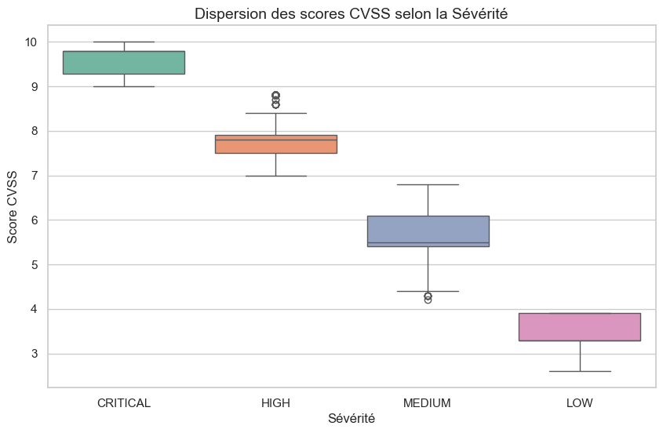

```python
plt.figure(figsize=(10, 6))
sns.boxplot(data=df.dropna(subset=['Score CVSS', 'Base Severity']), x='Base Severity', y='Score CVSS', palette="Set2")
plt.title("Dispersion des scores CVSS selon la Sévérité", fontsize=14)
plt.xlabel("Sévérité", fontsize=12)
plt.ylabel("Score CVSS", fontsize=12)
plt.savefig("boxplot_severity.png", dpi=100, bbox_inches='tight')
plt.show()
```

### 3.10. Analyse des éditeurs les plus affectés par type de bulletin (Avis vs Alerte)

Nous étudions ici les 10 éditeurs (Vendors) les plus fréquemment mentionnés dans nos données, en distinguant la répartition entre les bulletins d'Avis (vulnérabilités de routine) et les bulletins d'Alerte (vulnérabilités critiques activement exploitées).

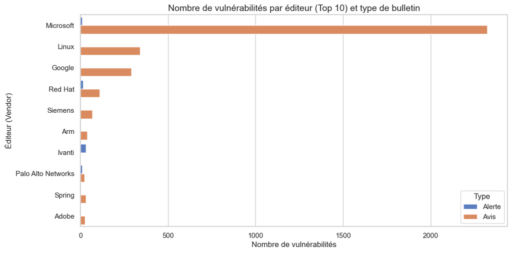

```python
plt.figure(figsize=(12, 6))
df_valid_vendor = df[df['Vendor'].notnull() & (df['Vendor'] != 'Non disponible') & (df['Vendor'] != '')]
top_vendors_names = df_valid_vendor['Vendor'].value_counts().head(10).index
df_top_vendors = df_valid_vendor[df_valid_vendor['Vendor'].isin(top_vendors_names)]

sns.countplot(data=df_top_vendors, y='Vendor', hue='Type', order=top_vendors_names, palette='muted')
plt.title('Nombre de vulnérabilités par éditeur (Top 10) et type de bulletin', fontsize=14)
plt.xlabel('Nombre de vulnérabilités', fontsize=12)
plt.ylabel('Éditeur (Vendor)', fontsize=12)
plt.savefig('top_vendors_by_type.png', dpi=100, bbox_inches='tight')
plt.show()
```

### 3.11. Dispersion des scores CVSS pour les principaux éditeurs

[figure not shown]

```python
plt.figure(figsize=(12, 6))
top_5_vendors = df_valid_vendor['Vendor'].value_counts().head(5).index
df_top_5 = df_valid_vendor[df_valid_vendor['Vendor'].isin(top_5_vendors)].dropna(subset=['Score CVSS'])

sns.boxplot(data=df_top_5, x='Vendor', y='Score CVSS', palette='Pastel1')
plt.title('Dispersion des scores CVSS pour les 5 éditeurs les plus affectés', fontsize=14)
plt.xlabel('Éditeur (Vendor)', fontsize=12)
plt.ylabel('Score CVSS', fontsize=12)
plt.savefig('boxplot_cvss_by_vendor.png', dpi=100, bbox_inches='tight')
plt.show()
```

### 3.12. Évolution cumulative du nombre de vulnérabilités publiées

Contrairement à la courbe de publication mensuelle, cette visualisation représente la courbe cumulative (la somme cumulée des failles) au cours du temps, ce qui permet de mesurer l'accélération ou la régularité des publications de bulletins de sécurité.

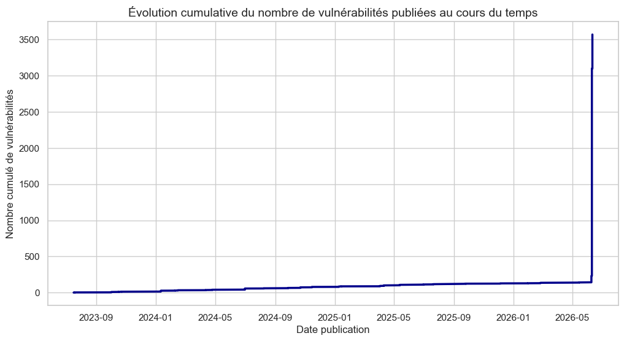

```python
plt.figure(figsize=(12, 6))
df_time = df.copy()
df_time['Date publication'] = pd.to_datetime(df_time['Date publication'], errors='coerce')
df_time_clean = df_time.dropna(subset=['Date publication']).sort_values('Date publication')
df_time_clean['Count_Cumulative'] = range(1, len(df_time_clean) + 1)

plt.plot(df_time_clean['Date publication'], df_time_clean['Count_Cumulative'], color='darkblue', linewidth=2.5)
plt.title('Évolution cumulative du nombre de vulnérabilités publiées au cours du temps', fontsize=14)
plt.xlabel('Date publication', fontsize=12)
plt.ylabel('Nombre cumulé de vulnérabilités', fontsize=12)
plt.savefig('cumulative_time_evolution.png', dpi=100, bbox_inches='tight')
plt.show()
```

### 3.13. Versions de logiciels les plus fréquemment touchées

Nous analysons ici les versions de produits les plus touchées afin d'identifier si des versions spécifiques reviennent très régulièrement dans les failles recensées.

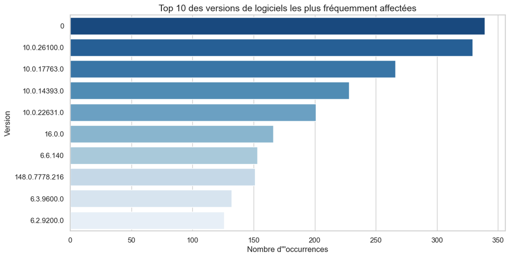

```python
import ast

def parse_versions(v):
    if pd.isna(v):
        return []
    v_str = str(v).strip()
    if not v_str:
        return []
    try:
        if v_str.startswith('[') and v_str.endswith(']'):
            parsed = ast.literal_eval(v_str)
            if isinstance(parsed, list):
                return parsed
        return [v_str]
    except:
        return [v_str]

df_versions = df.copy()
df_versions['versions_list'] = df_versions['Versions affectées'].apply(parse_versions)
all_versions = [item for sublist in df_versions['versions_list'] for item in sublist if str(item).strip() not in ['', 'nan', 'n/a', 'Non disponible']]
version_counts = pd.Series(all_versions).value_counts().head(10)

plt.figure(figsize=(12, 6))
sns.barplot(x=version_counts.values, y=version_counts.index, palette='Blues_r')
plt.title('Top 10 des versions de logiciels les plus fréquemment affectées', fontsize=14)
plt.xlabel("Nombre d'''occurrences", fontsize=12)
plt.ylabel('Version', fontsize=12)
plt.savefig('top_affected_versions.png', dpi=100, bbox_inches='tight')
plt.show()
```

## 4. Machine Learning Non Supervisé (Clustering)

Nous cherchons à partitionner les vulnérabilités en plusieurs groupes (clusters) homogènes selon leur Score CVSS et leur Score EPSS. Nous utilisons l'algorithme K-Means. Nous appliquons d'abord la méthode du coude pour déterminer le nombre optimal de clusters.

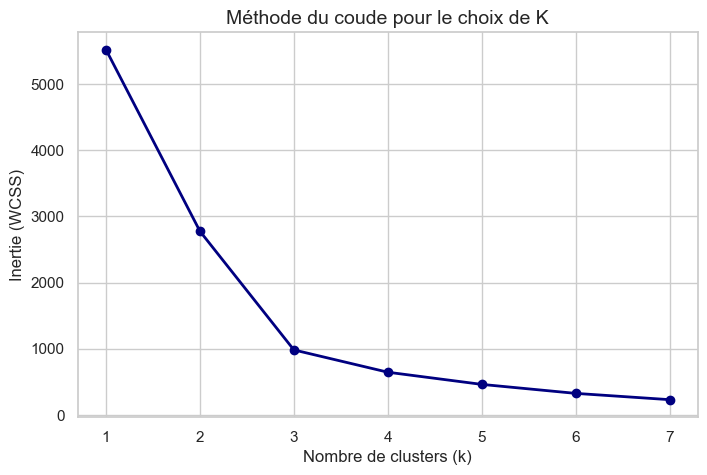

```python
from sklearn.cluster import KMeans
from sklearn.preprocessing import StandardScaler

# Nettoyage pour le Clustering
df_ml = df.dropna(subset=['Score CVSS', 'Score EPSS'])
X_clust = df_ml[['Score CVSS', 'Score EPSS']]

# Standardisation des données
scaler = StandardScaler()
X_scaled = scaler.fit_transform(X_clust)

# Détermination du K optimal par la méthode du coude
wcss = []
k_range = range(1, 8)
for k in k_range:
    kmeans = KMeans(n_clusters=k, random_state=42, n_init=10)
    kmeans.fit(X_scaled)
    wcss.append(kmeans.inertia_)

plt.figure(figsize=(8, 5))
plt.plot(k_range, wcss, 'o-', color='navy', linewidth=2)
plt.title("Méthode du coude pour le choix de K", fontsize=14)
plt.xlabel("Nombre de clusters (k)", fontsize=12)
plt.ylabel("Inertie (WCSS)", fontsize=12)
plt.savefig("elbow_method.png", dpi=100, bbox_inches='tight')
plt.show()
```

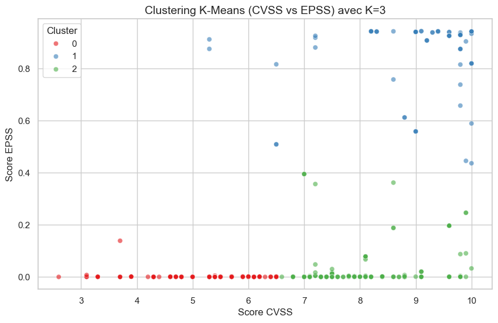

```
=== Valeurs moyennes des indicateurs par cluster ===
         Score CVSS  Score EPSS
Cluster
0          5.339232    0.000940
1          9.023188    0.855305
2          7.852199    0.003321
```

```python
# Choix de K = 3 clusters
kmeans_opt = KMeans(n_clusters=3, random_state=42, n_init=10)
df_ml['Cluster'] = kmeans_opt.fit_predict(X_scaled)

plt.figure(figsize=(10, 6))
sns.scatterplot(data=df_ml, x='Score CVSS', y='Score EPSS', hue='Cluster', palette='Set1', alpha=0.6)
plt.title("Clustering K-Means (CVSS vs EPSS) avec K=3", fontsize=14)
plt.xlabel("Score CVSS", fontsize=12)
plt.ylabel("Score EPSS", fontsize=12)
plt.savefig("kmeans_clusters.png", dpi=100, bbox_inches='tight')
plt.show()

print("=== Valeurs moyennes des indicateurs par cluster ===")
print(df_ml.groupby('Cluster')[['Score CVSS', 'Score EPSS']].mean())
```

## 5. Machine Learning Supervisé (Classification)

Notre but est de prédire si une vulnérabilité présente une **criticité extrême (Score CVSS >= 9.0, c'est-à-dire une classification 'CRITICAL')**. Nous utilisons pour cela les attributs de la vulnérabilité comme le score EPSS, le fait que ce soit une alerte ou un avis ANSSI, et les CWE / Vendors les plus représentés. Nous entraînons un classifieur de type **Random Forest**.

```
=== Performances du Modèle de Classification Random Forest ===
Accuracy du modèle : 0.9710

Rapport de classification :
              precision    recall  f1-score   support

           0       0.98      0.99      0.98       772
           1       0.85      0.70      0.76        56

    accuracy                           0.97       828
   macro avg       0.91      0.84      0.87       828
weighted avg       0.97      0.97      0.97       828
```

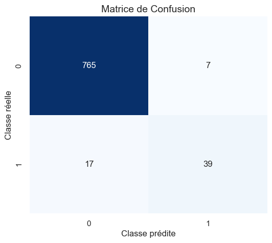

```python
from sklearn.model_selection import train_test_split
from sklearn.ensemble import RandomForestClassifier
from sklearn.metrics import classification_report, confusion_matrix, accuracy_score

# Variable cible
df_ml['Is_Critical'] = (df_ml['Score CVSS'] >= 9.0).astype(int)

# Features
df_ml['Is_Alert'] = (df_ml['Type'] == 'Alerte').astype(int)

# Encodage binaire pour les CWE et Vendors les plus courants
top_cwe_list = df_ml['Type CWE'].value_counts().head(10).index
top_vendor_list = df_ml['Vendor'].value_counts().head(10).index

X = df_ml[['Score EPSS', 'Is_Alert']].copy()
for cwe in top_cwe_list:
    X[f'CWE_{cwe}'] = (df_ml['Type CWE'] == cwe).astype(int)
for vendor in top_vendor_list:
    X[f'Vendor_{vendor}'] = (df_ml['Vendor'] == vendor).astype(int)

y = df_ml['Is_Critical']

# Séparation d'entraînement et de test
X_train, X_test, y_train, y_test = train_test_split(X, y, test_size=0.3, random_state=42, stratify=y)

# Entraînement
rf = RandomForestClassifier(n_estimators=100, random_state=42, max_depth=10)
rf.fit(X_train, y_train)

# Prédiction
y_pred = rf.predict(X_test)

# Évaluation
print("=== Performances du Modèle de Classification Random Forest ===")
print(f"Accuracy du modèle : {accuracy_score(y_test, y_pred):.4f}\n")
print("Rapport de classification :")
print(classification_report(y_test, y_pred))

# Matrice de confusion
plt.figure(figsize=(6, 5))
cm = confusion_matrix(y_test, y_pred)
sns.heatmap(cm, annot=True, fmt='d', cmap='Blues', cbar=False)
plt.title("Matrice de Confusion", fontsize=14)
plt.ylabel("Classe réelle", fontsize=12)
plt.xlabel("Classe prédite", fontsize=12)
plt.savefig("confusion_matrix.png", dpi=100, bbox_inches='tight')
plt.show()
```

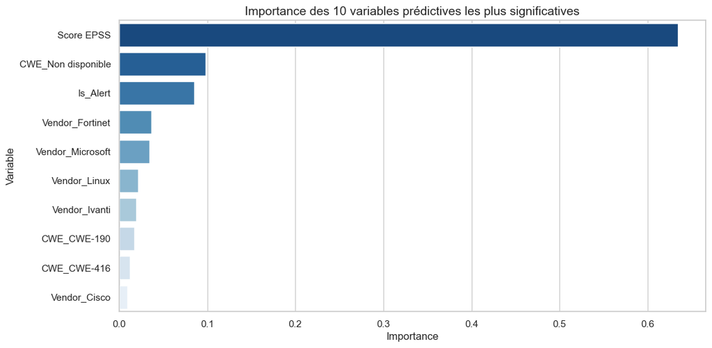

```python
# Tracé de l'importance des variables
importances = rf.feature_importances_
indices = np.argsort(importances)[::-1]

plt.figure(figsize=(12, 6))
sns.barplot(x=importances[indices[:10]], y=X.columns[indices[:10]], palette="Blues_r")
plt.title("Importance des 10 variables prédictives les plus significatives", fontsize=14)
plt.xlabel("Importance", fontsize=12)
plt.ylabel("Variable", fontsize=12)
plt.savefig("feature_importances.png", dpi=100, bbox_inches='tight')
plt.show()
```